# Manifestation of the climate change in Texas from 1950 until today

Hans-Christian Lindner Institute for Geoinformatics Münster, Germany h_lind04@uni-muenster.de

16th of March 2018

## Abstract

We know about the climate change and its consequences since many years and a lot of research has been done in this field. The climate is a complex system compound of different elements like temperature, precipitation or wind. This paper aims to analyse the power of the climate change regarding these elements on the example of Texas. The effects of the climate change on air temperature, precipitation, wind speed and evaporation will be investigated. By analysing time series and kriging interpolations of data from weather stations across the state it showed out, that there is a remarkable climate change. The temperature is rising, precipitation slightly increases, wind speed slowed, and evaporation becomes weaker. This paper gives another evidence to the climate change and together with other examples we should take future political decisions with respect to research in this field.

## Introduction

Since Charles David Keeling presented his findings of an increase in the concentration of carbon dioxide in Earth’s atmosphere, people started believing in a human influenced climate change (Keeling, 1960). Before that, the natural variability of the Earth’s climate with changes into both extremes, cold and warm, over the last 800.000 years was known (Jouzel et al. 2007). Based on Keelings data and other climatic investigations it became clear that the current global warming is strongly human-induced. Since then, many started investigating the impact of the climate change on natural and human environment. Above all the IPCC, the Intergovernmental Panel on Climate Change, provides information about the human-induced climate change, the risks and consequences of it and the possibilities of a climate mitigation (IPCC, 2018). The summarized findings of their researcher groups show that there is a remarkable rise of temperature and a lot of significant changes in physical and biological systems in all parts of the earth (IPCC Working Group 1, 2007). Another working group shows the influence of the humans in the climate change (IPCC Working Group 2, 2007). To show how the climate change influences some of the most important climate elements: air temperature, precipitation, wind speed and evaporation, this paper investigates data gathered from weather stations all over Texas. Texas was chosen because it is a very large state (696,241 km2), is climatically interesting (containing three climate zones) and has a lot of easy accessible data (Texas Almanac, 2018). On top of that, Texas emits the most greenhouse gases of all states in the United States which makes it to a massive climate sinner (DallasNews, 2007). In addition to the book “The impact of global warming on Texas”, by Schmandt et al., this paper takes a deeper look into data from single stations. In their work they gave an overview for the whole state regarding different climatic, biological and political factors and were able to show a remarkable climate change for precipitation and temperature (Schmandt et al., 2011). In this work the focus lies on single stations and interpolated data out of that. Additionally, it will be checked if there are differences between the climate change at the coast and at the interior and a forecast for the next years will be given. This work starts by introducing the used data and how it was gathered. After that, the methods will be described which were used to analyse the data. This is followed by a presentation of the results and a discussion of the findings. It will be closed by a conclusion with an outlook to further research.

## Data

Two different types of data are used for the analysis:

- Daily time series data of four weather stations in Texas from 1950 until today
- Averaged data of all weather stations in Texas of January and August every ten years from 1955 on

The datasets involve the location of the station, the name and identifier of the station, the date of the observation and the measured value. The four measured climate elements are:

- Maximum air temperature
- Total precipitation
- Average wind speed
- Total evaporation from an evaporation pan

The four stations with the time series data were chosen to represent different parts of Texas. To test if there are differences between the coastal regions and the interior, one station for each of the four cardinal directions north, east, south and west were chosen.

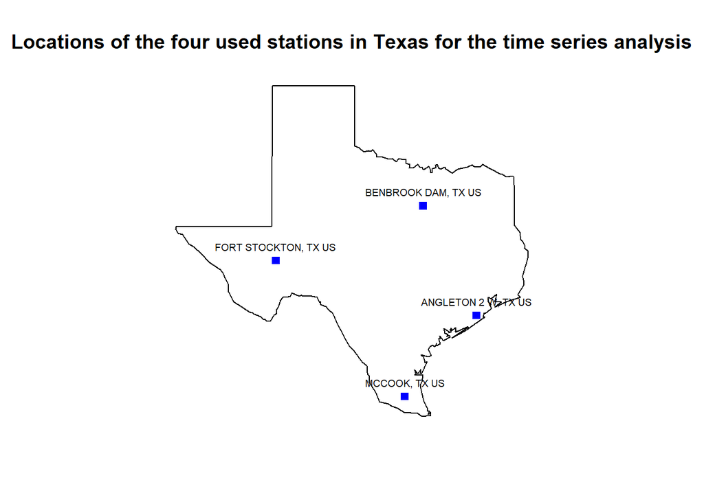

Since by the chosen stations only measured the total wind movement instead of average wind speed, this is used for the analysis. The total wind movement are the summed wind speeds for one day. The temporal amount of the time series reaches from 1950 until today. Not every series of data from the four stations covers the whole extent, but the chosen ones are the best fitting stations in sense of location and data coverage for this analysis. Missing data for single days is interpolated or left out if longer periods are missing.

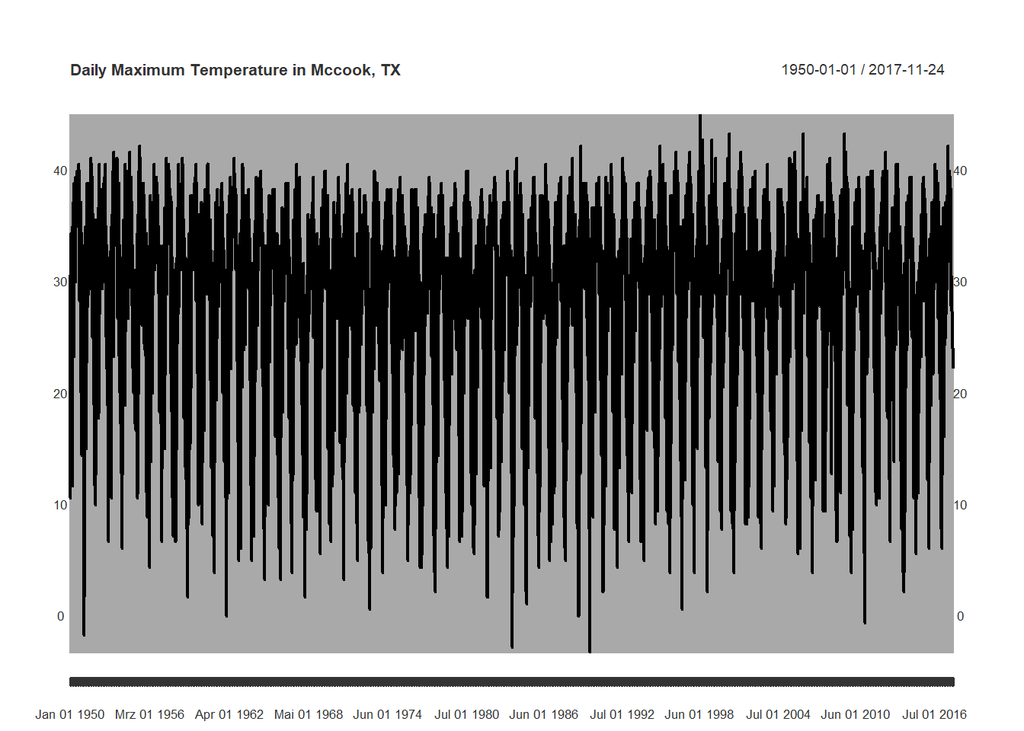

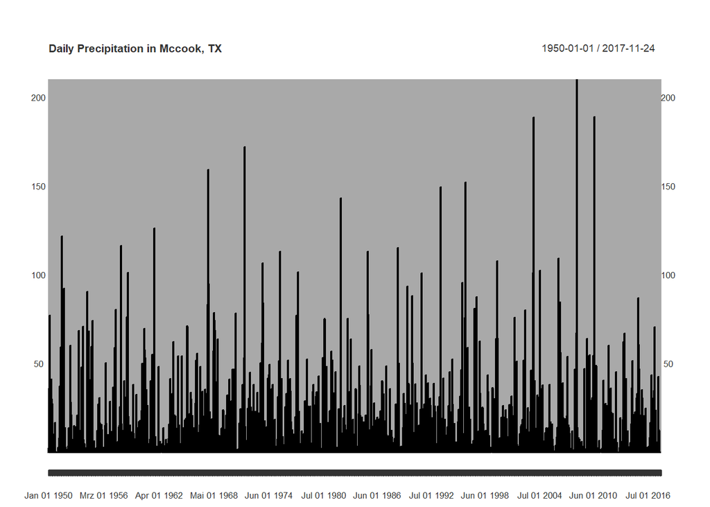

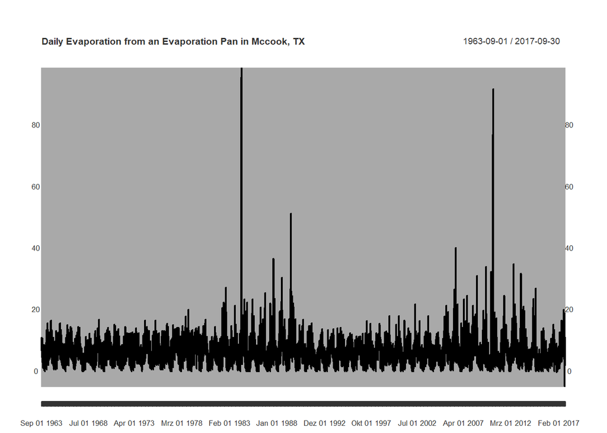

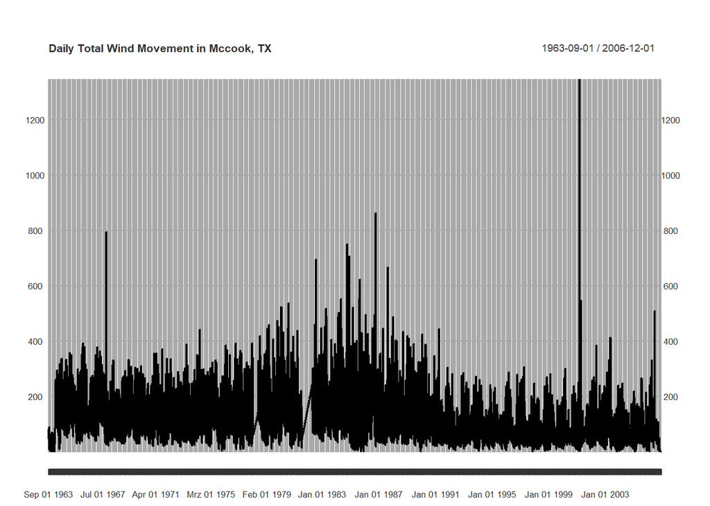

The data of entire Texas includes more than 4500 weather stations but not every station measured all presented climate elements. The values from January and August are averaged daily measurements to get more representative data. Missing data for single days will be omit in the average computation.

```r
#head of the averaged temperature dataset of Texas in January 2015 with UTM coordinates
head(JanTmpMax2015Subset[c(1,2,3,4,7)])
```

```
##           coordinates     STATION               NAME LATITUDE LONGITUDE
## 1 (792109.7, 3748211) USC00410012   ABERNATHY, TX US  33.8338 -101.8436
## 2   (860340, 3363741) USC00410040 ACTON RANCH, TX US  30.3519 -101.2519
## 3  (1034503, 3632942) USC00410120      ALBANY, TX US  32.7047  -99.3011
## 4 (628755.3, 3361245) USC00410174      ALPINE, TX US  30.3763 -103.6600
## 5 (617154.4, 3360449) USC00410176 ALPINE 7 NW, TX US  30.3703 -103.7808
## 6  (1178154, 3717944) USC00410206  ALVORD 3 N, TX US  33.3866  -97.7163
##   meanTemp
## 1   8.7000
## 2  11.0647
## 3  11.2097
## 4  13.2645
## 5  11.6677
## 6  11.2806
```

```r
#head of the averaged precipitation dataset of Texas in January 2015 with UTM coordinates
head(JanPrcp2015Subset[c(1,2,3,4,7)])
```

```
##           coordinates     STATION                       NAME LATITUDE
## 1  (1091603, 3734247) US1TXAC0003 ARCHER CITY 0.7 SSW, TX US  33.5838
## 2  (1468576, 3510125) US1TXAG0001        LUFKIN 7.0 W, TX US  31.3213
## 3  (1514467, 3494779) US1TXAG0002     ZAVALLA 2.0 ESE, TX US  31.1464
## 4  (1476603, 3508860) US1TXAG0003       LUFKIN 3.0 SW, TX US  31.3034
## 5  (1480404, 3511223) US1TXAG0005      LUFKIN 0.9 SSE, TX US  31.3212
## 6 (811056.5, 3872232) US1TXAM0002      CLAUDE 17.3 SW, TX US  34.9449
##   LONGITUDE meanPrcp
## 1  -98.6298   2.0000
## 2  -94.8445   5.2586
## 3  -94.3856   7.2419
## 4  -94.7627   7.5387
## 5  -94.7211   6.8065
## 6 -101.5942   9.9000
```

```r
#head of the averaged evaporation dataset of Texas in January 2015 with UTM coordinates
head(JanEvap2015Subset[c(1,2,3,4,7)])
```

```
##           coordinates     STATION                            NAME LATITUDE
## 1 (885246.4, 3265613) USC00410225              AMISTAD DAM, TX US  29.4608
## 2  (1288886, 3600456) USC00410518             BARDWELL DAM, TX US  32.2630
## 3  (1534989, 3375223) USC00410613      BEAUMONT RESRCH CTR, TX US  30.0688
## 4  (1215163, 3169651) USC00410639            BEEVILLE 5 NE, TX US  28.4575
## 5  (1209516, 3637539) USC00410691             BENBROOK DAM, TX US  32.6475
## 6 (831054.6, 3575600) USC00410784 BIG SPRING FIELD STATION, TX US  32.2683
##   LONGITUDE meanEvap
## 1 -101.0286   3.0933
## 2  -96.6369   5.8760
## 3  -94.2927   2.2462
## 4  -97.7061   4.3353
## 5  -97.4439   3.3192
## 6 -101.4858   3.9143
```

```r
#head of the averaged wind speed dataset of Texas in January 2015 with UTM coordinates
head(JanWind2015Subset[c(1,2,3,4,7)])
```

```
##           coordinates     STATION                                NAME
## 1  (1410625, 3503308) USC00412114                     CROCKETT, TX US
## 2  (1439390, 3244710) USC00413340                FREEPORT 2 NW, TX US
## 3   (812228, 3956698) USC00418040                  SANFORD DAM, TX US
## 4  (1228205, 3408158) USC00418862                  TAYLOR 1 NW, TX US
## 5 (826225.8, 3956113) USW00003024 BORGER HUTCHINSON CO AIRPORT, TX US
## 6 (747093.6, 3534611) USW00003031      ODESSA SCHLEMEYER FIELD, TX US
##   LATITUDE LONGITUDE meanWind
## 1 31.30720  -95.4509   1.9700
## 2 28.98450  -95.3809   4.1968
## 3 35.70480 -101.5492   3.7032
## 4 30.58440  -97.4156   3.1194
## 5 35.69500 -101.3950   3.9742
## 6 31.92056 -102.3867   4.0000
```

The data is provided by the National Oceanic and Atmospheric Administration (NOAA) which is a scientific agency within the United Stated Department of Commerce (NOAA, 2018). Environmental data is publicly available on their website and is accessible by an interactive web service.

## Methods

The two different types of data were analysed with different methods. The time series data of the four stations in Texas were first converted into an `xts` object which provides nice visualizations and makes the handling of them easier. The autocorrelation and partial autocorrelation is computed to see if the data is autocorrelated. The trend of the time series gets extracted with the help of the `stl` function. The trends of the different stations are compared to see differences. A linear model representing the trend is fitted to simplify the comparison. A forecast is made to look on the future development of the climate. Additionally, some basic statistical parameters will be computed. The averaged data of all stations were first extended by WGS84 coordinates by converting the given numeric values for Latitude and Longitude. After that the coordinates were transformed into UTM coordinates so that linear units can be used. To compare the data from different years, a kriging interpolation was conducted for every parameter in every given dataset. To be able to do that, a variogram needs to be computed and a suitable model needs to be fitted. For every dataset of the climate elements the same variogram model was fitted to get comparable results. To predict the values of the locations where no measurement was made, a spatial grid is needed. In this case the map of Texas out of the `map` library was used and a regular grid was placed over it. Subsequent, ordinary kriging was performed and the results were visually compared.

## Results

In this chapter the results will be described, divided into the four investigated climate elements: Temperature, Precipitation, Evaporation and Wind.

### Temperature

#### Time series data

In the four temperature time series of the four stations in Texas from 1950 until today you can see the yearly periodicities as well as the high variability between summer and winter. They all show a general rise of temperature which gets clearer if we look only on the trend.

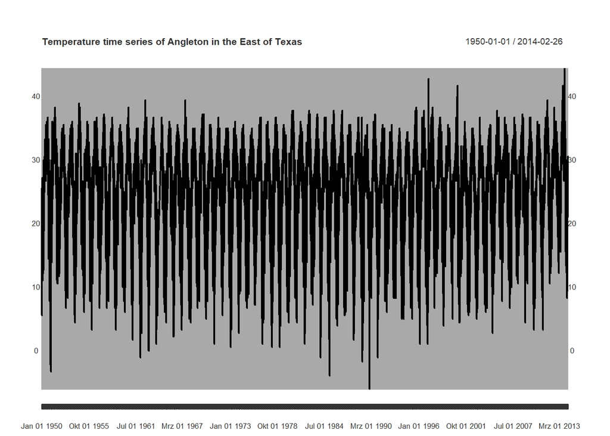

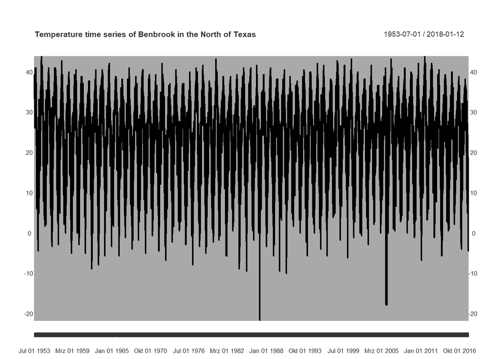

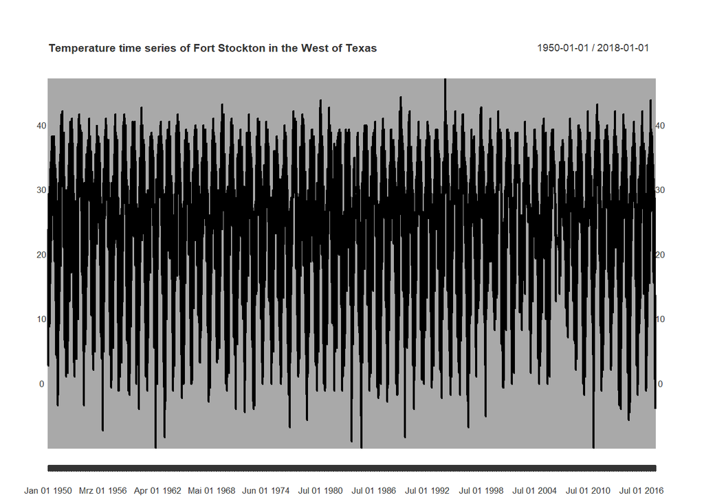

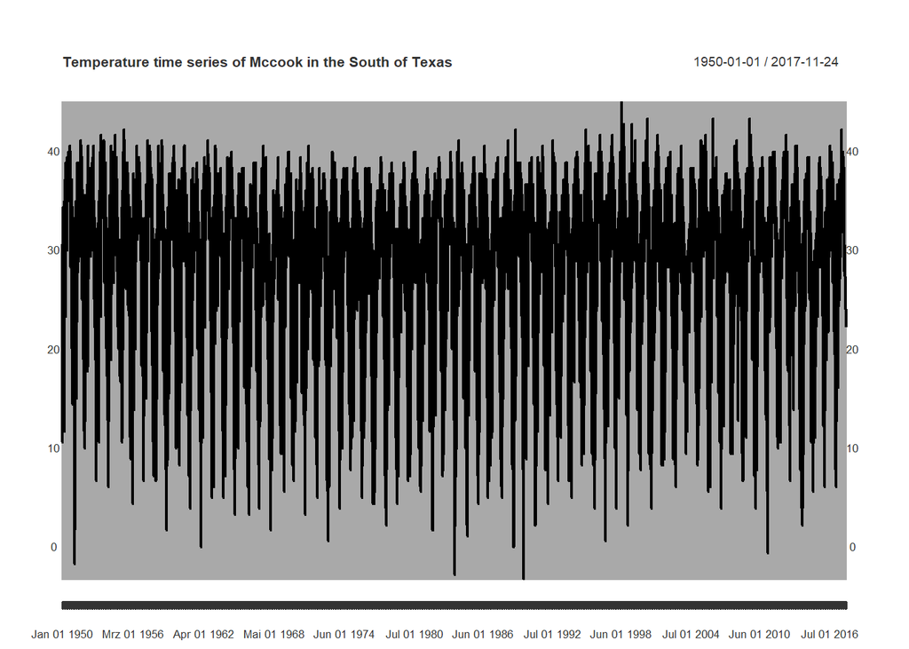

The trend of the temperature time series still shows a lot variability but with the help of the linear model we can see that every time series is increasing.

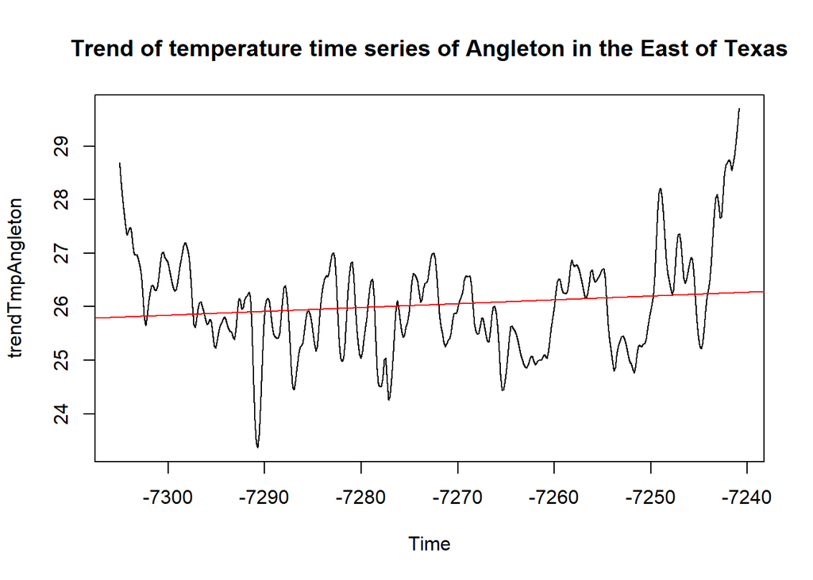

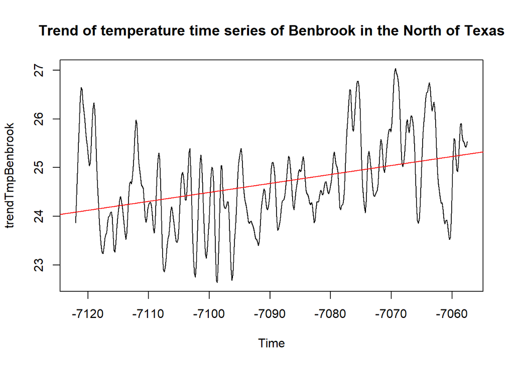

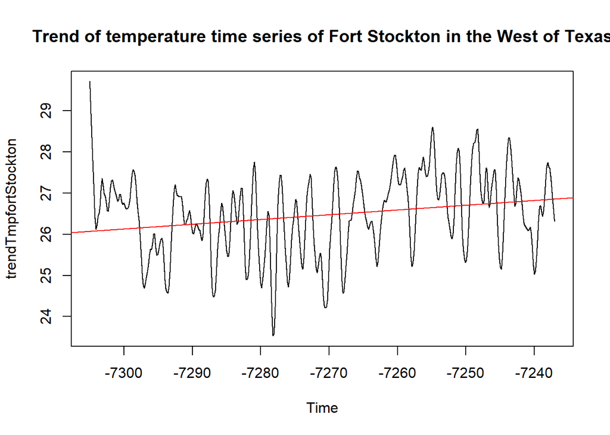

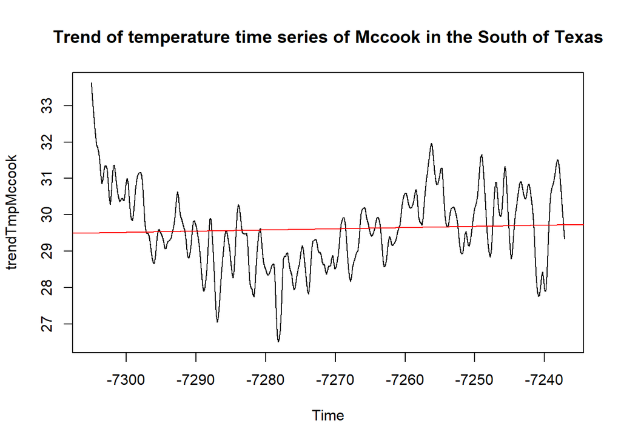

In the autocorrelation plot up to lag 365 of the time series, you can see the periodicity. In the summer the autocorrelation turns negative because of the deviation from the mean in the other direction.

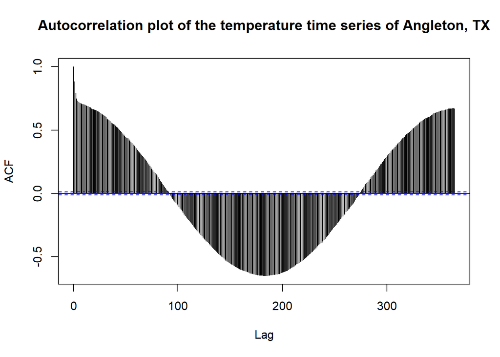

If we look on the forecasts for the next 100 days, we see that for the stations in Benbrook, Fort Stockton and Mccook a further increase is predicted. Only for the station of Angleton the forecast is nearly static but since the series ends in high temperatures a further increase would make no sense.

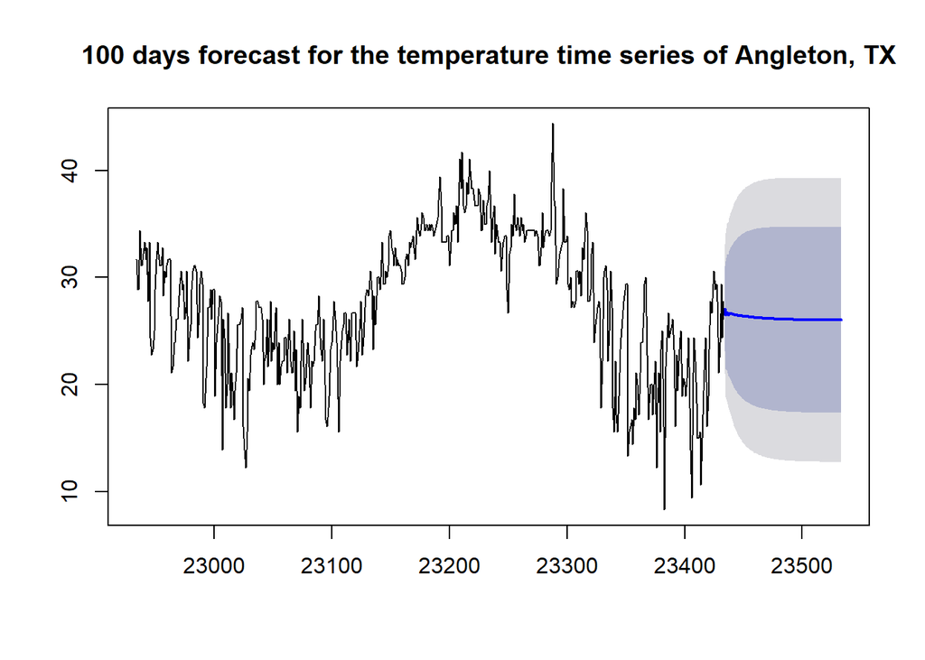

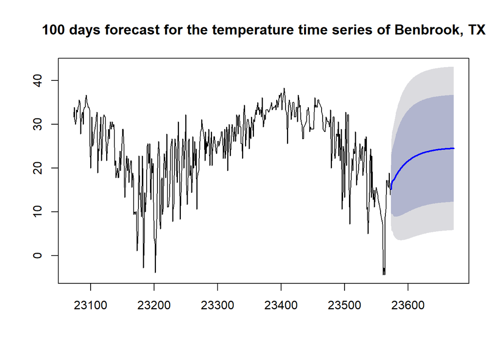

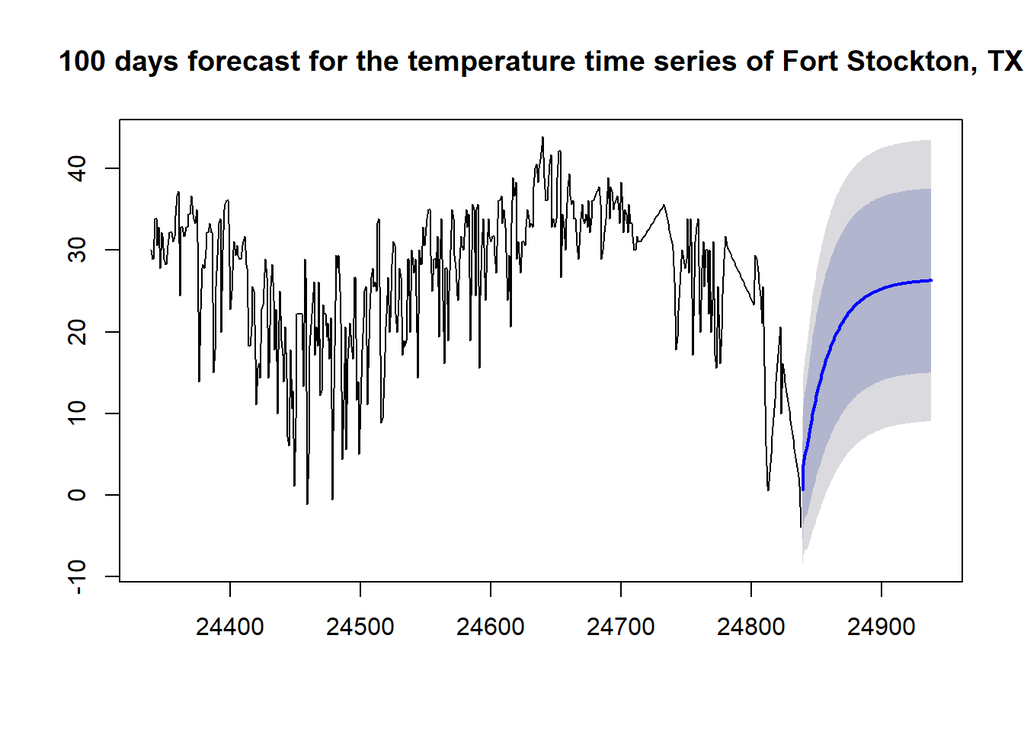

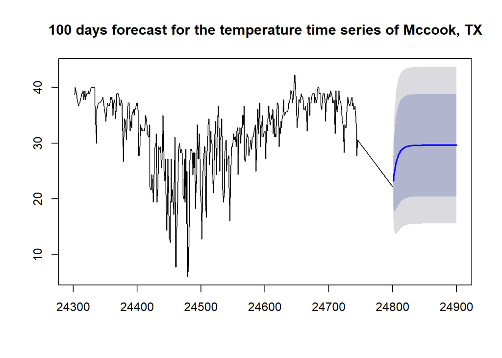

#### Averaged monthly data

Interestingly, the kriging interpolation results for the averaged maximum temperature data sets of January show no increasing trend. The plots show a clear division of temperature layers starting with the coldest in the north and getting warmer with less distance to the Gulf of Mexico in the south.

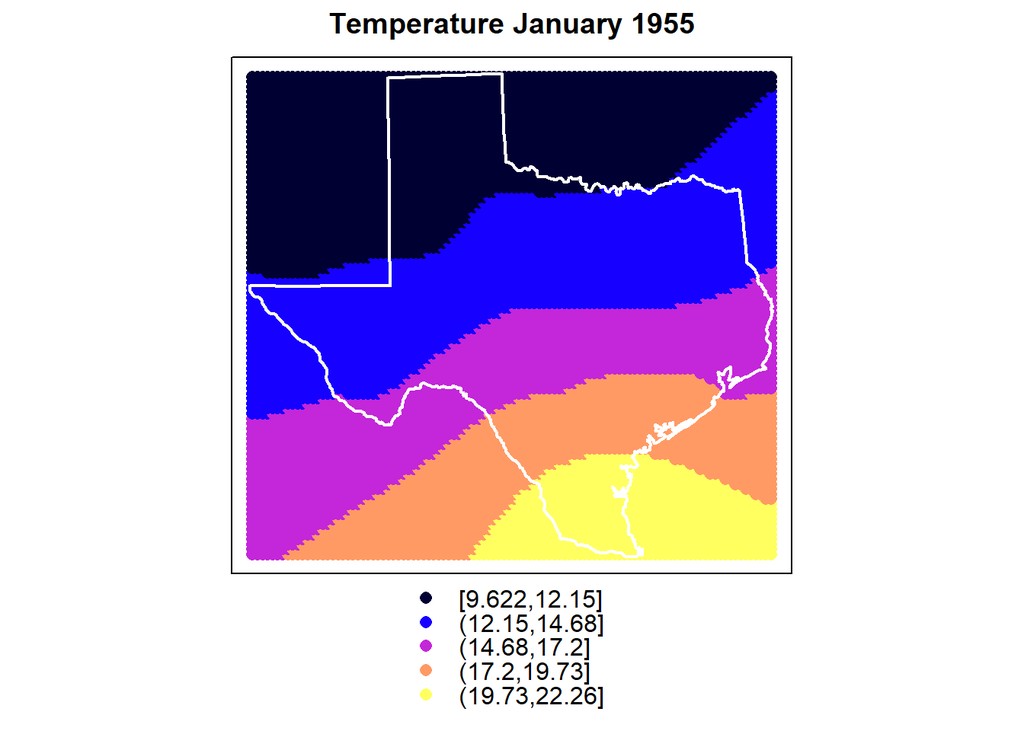

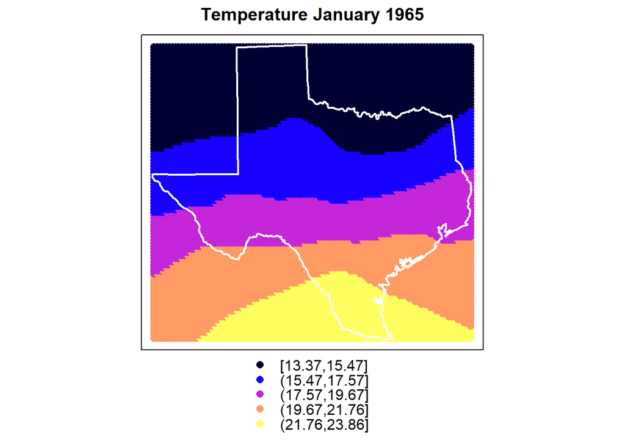

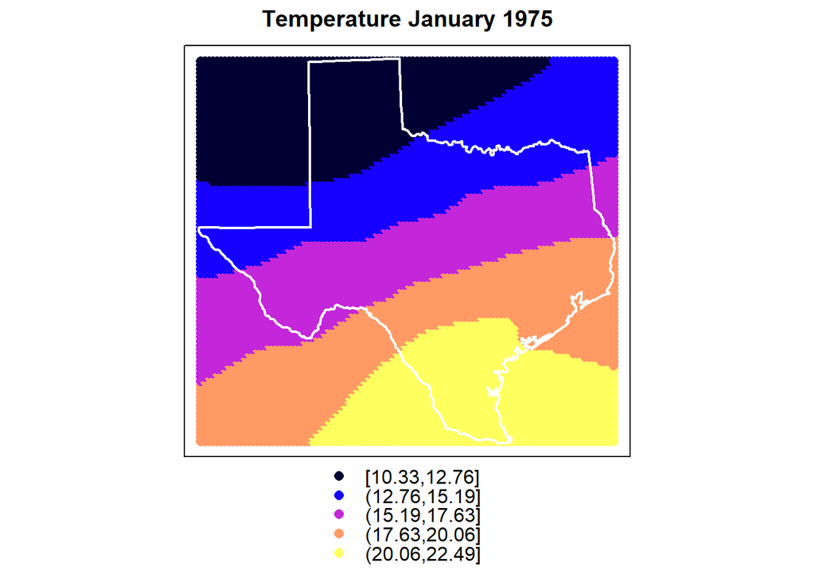

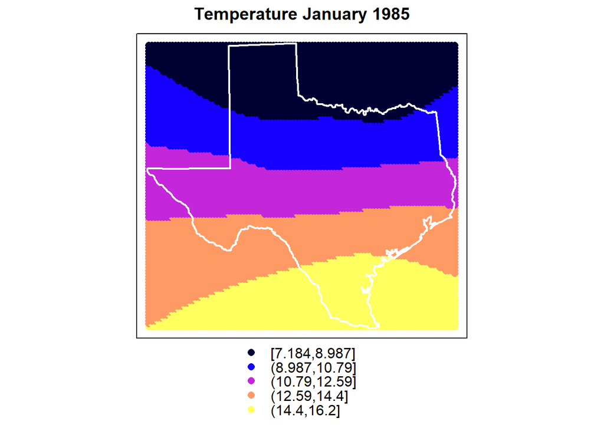

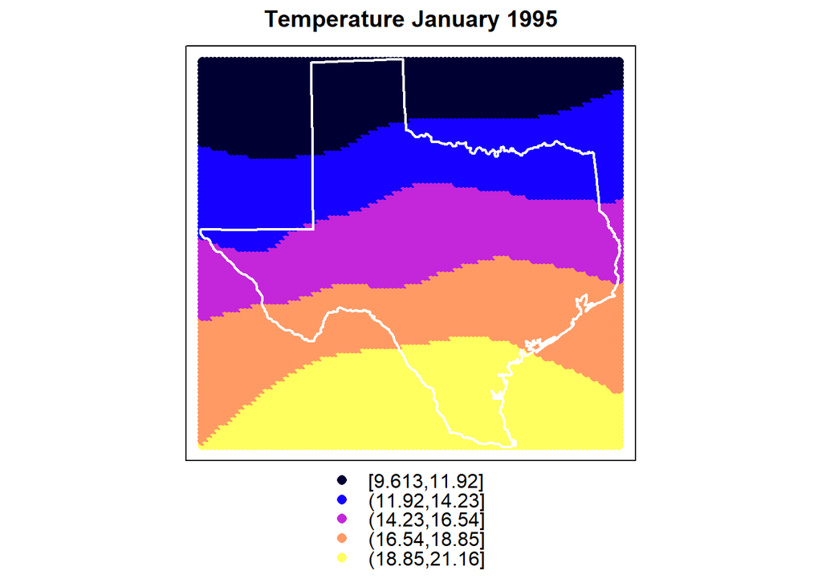

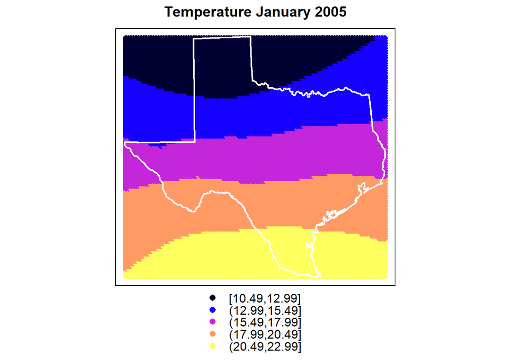

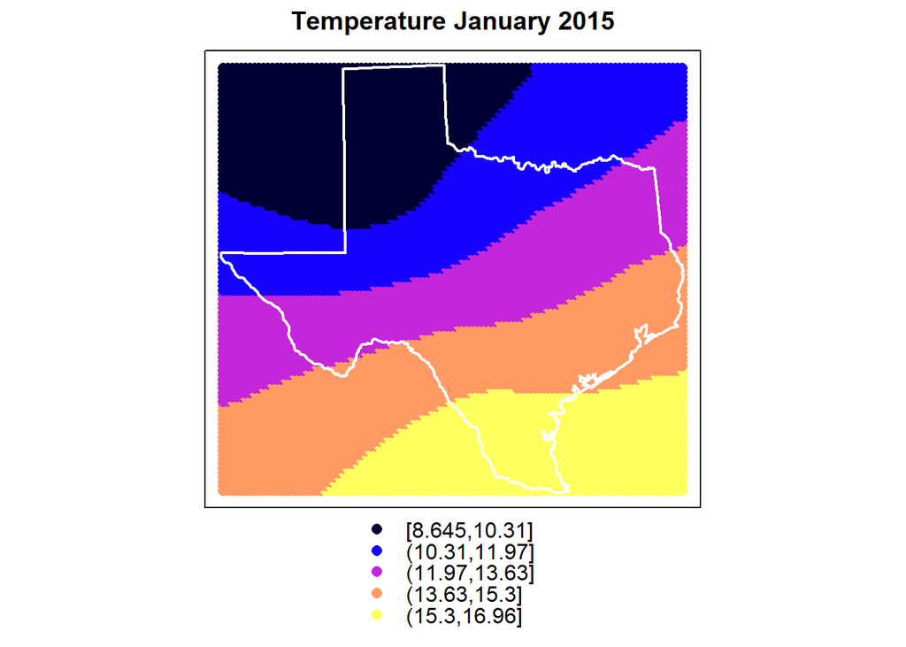

In addition to that, the comparison of the mean, minimum, maximum and standard deviation shows also no clear trend. The January 2015 was the second coldest after the January 1985 and the January 1965 was the warmest. The difference between 2015 and 1955 displays even a 2.2 degrees cooling.

Statistics of averaged Temperature values in January

|  | Mean | Min | Max | Std. Dev. |
| --- | --- | --- | --- | --- |
| 1955 | 15.069194 | 8.4226 | 23.0774 | 3.1056898 |
| 1965 | 17.609813 | 11.9387 | 24.8258 | 2.7534065 |
| 1975 | 16.531918 | 9.1194 | 24.8350 | 3.3307209 |
| 1985 | 11.508174 | 5.8581 | 18.1742 | 2.6348493 |
| 1995 | 15.592069 | 5.8690 | 22.7929 | 2.8885338 |
| 2005 | 16.893731 | 7.9161 | 27.2000 | 3.1714478 |
| 2015 | 12.848918 | 4.6333 | 20.0733 | 2.4834118 |
| Difference 2015 - 1955 | -2.220276 | -3.7893 | -3.0041 | -0.6222781 |

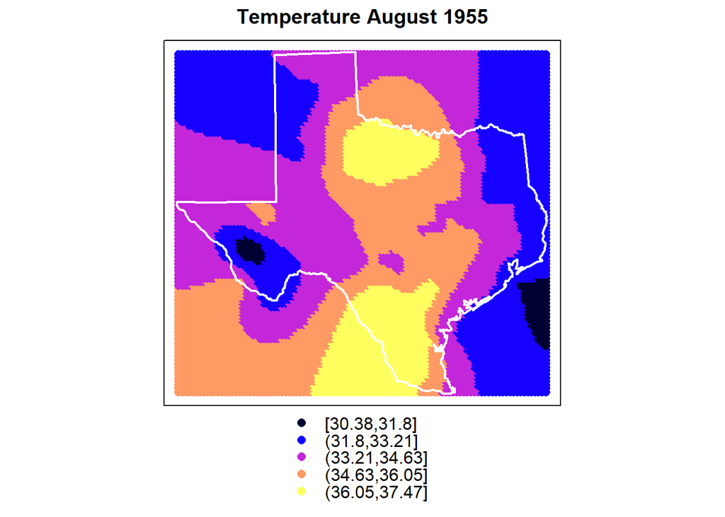

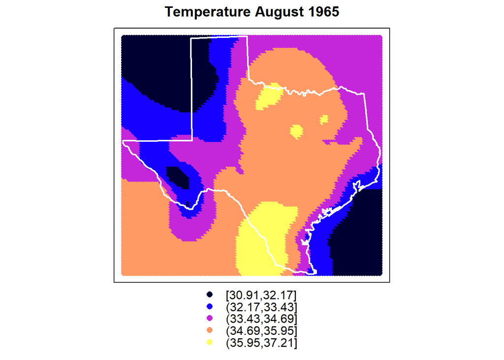

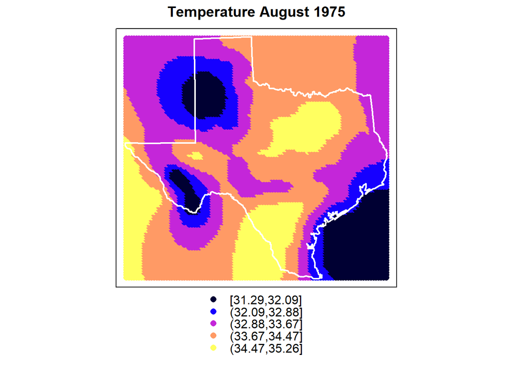

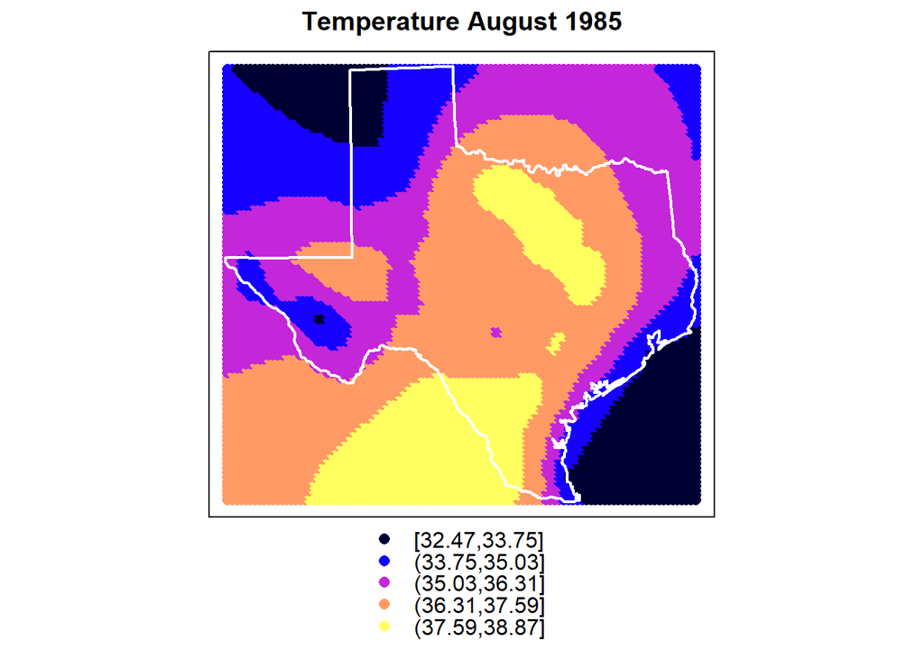

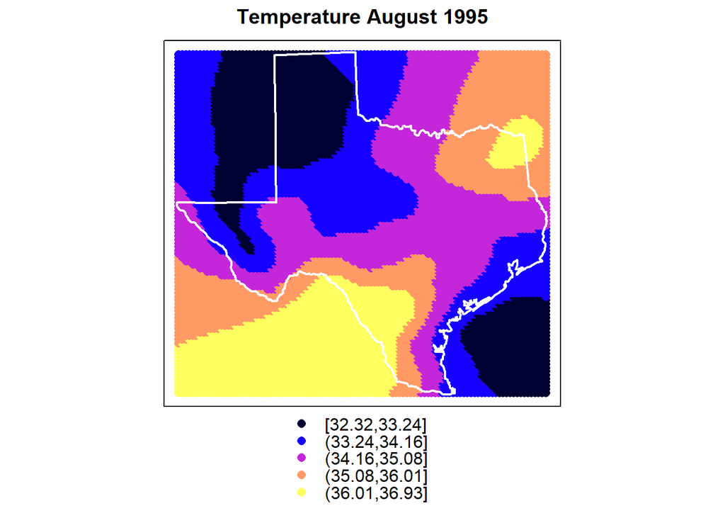

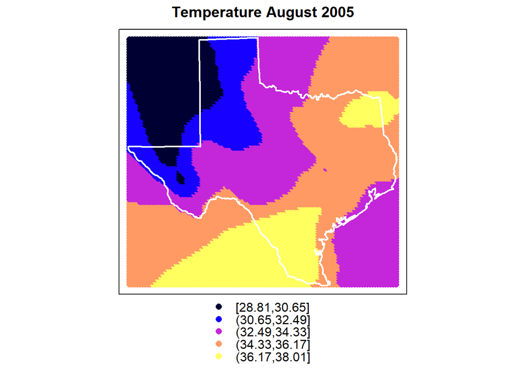

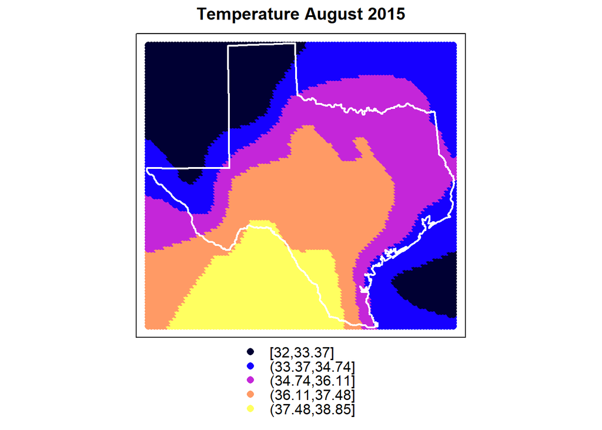

Statistics of averaged Temperature values in August

|  | Mean | Min | Max | Std. Dev. |
| --- | --- | --- | --- | --- |
| 1955 | 34.5487754 | 26.0806 | 38.5290 | 1.6758832 |
| 1965 | 34.5818284 | 27.1935 | 38.2613 | 1.5651563 |
| 1975 | 33.6633164 | 25.5129 | 38.3968 | 1.3399679 |
| 1985 | 36.3777769 | 27.5258 | 40.0581 | 1.8010499 |
| 1995 | 34.4257883 | 23.0323 | 39.3074 | 1.6614893 |
| 2005 | 34.2799484 | 21.4161 | 39.0161 | 2.2345021 |
| 2015 | 35.5351808 | 24.4323 | 41.1806 | 1.8423929 |
| Difference 2015 - 1955 | 0.9864054 | -1.6483 | 2.6516 | 0.1665097 |

#### Comparison coast interior

If we compare the slope of the trend of the temperature time series, we see that the rise is not very steep. Nevertheless, we can see an obvious difference between the slope at the coast and in the interior. The slope in the interior is more than twice as steep which could indicate a stronger change of temperature here. A reason for this could be the higher heat storage capacity of the water which weakens the change at the coast.

Slope of trend of the temperature time series on the coast and in the interior

|  | Slope of trend |
| --- | --- |
| Angleton, East (Coast) | 0.0072086 |
| Mccook, South (Coast) | 0.0034396 |
| Benbrook, North (Interior) | 0.0183587 |
| Fort Stockton, West (Interior) | 0.0114993 |
| Mean (Coast) | 0.0053241 |
| Mean(Interior) | 0.0149290 |

### Precipitation

#### Time series data

In the precipitation time series of the four stations you can already see by the different y-axis that the amount of rainfall is very diverse in different parts of Texas. Since there are many peaks in the data it is hard to recognize a trend.

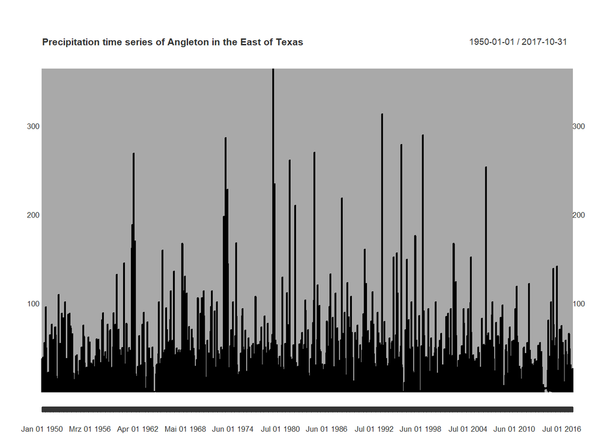

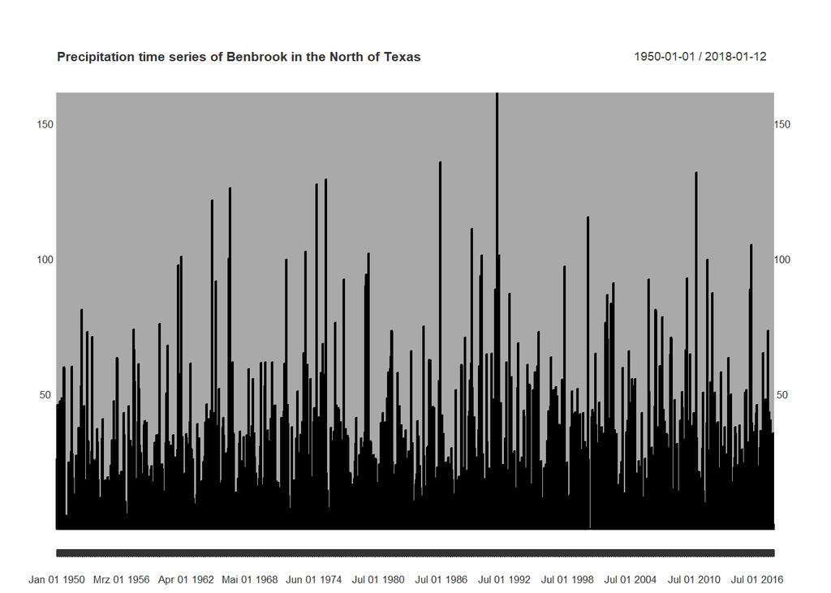

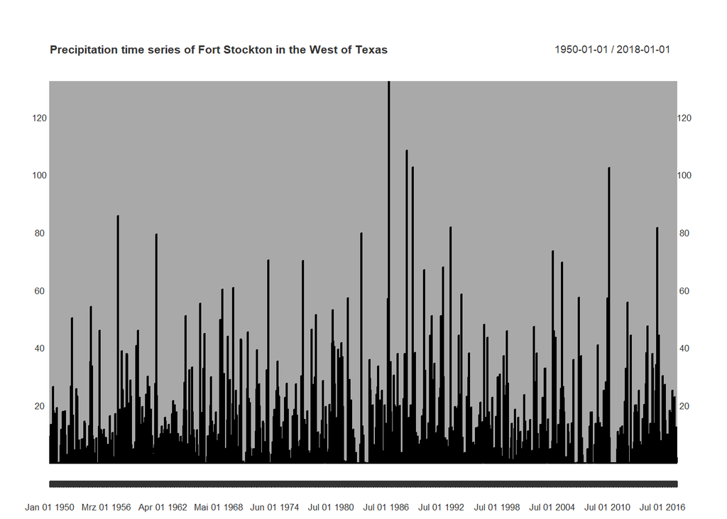

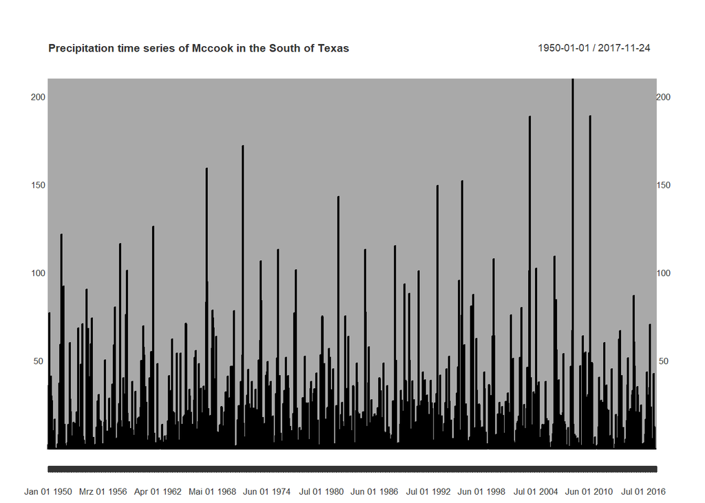

If we only plot the trend of the time series, we see that there is a general rise in precipitation. By comparing these, we see that three of the four stations have an increasing precipitation and only in Mccook the trend is falling a little. Since Mccook had the highest rise in temperature values this could be an explanation for absent precipitation.

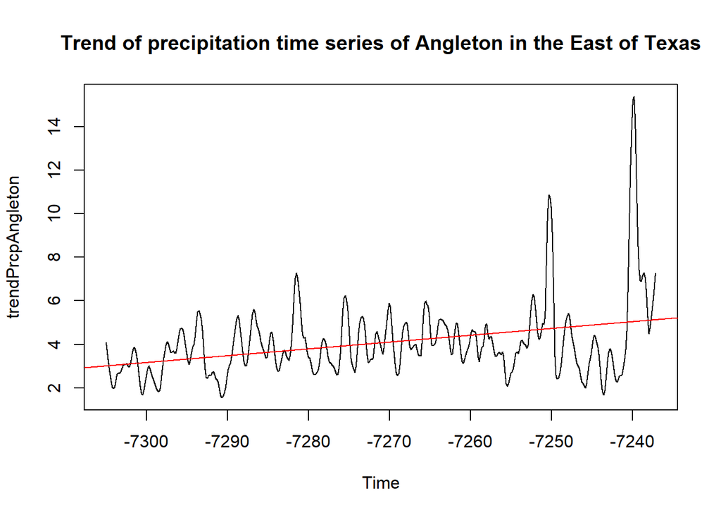

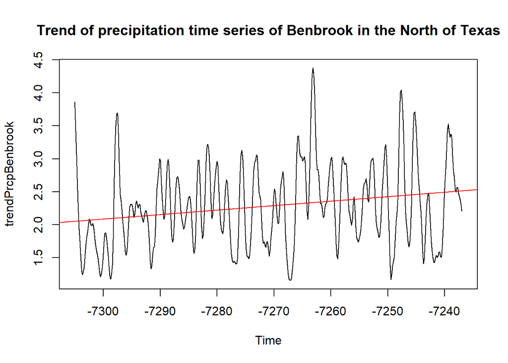

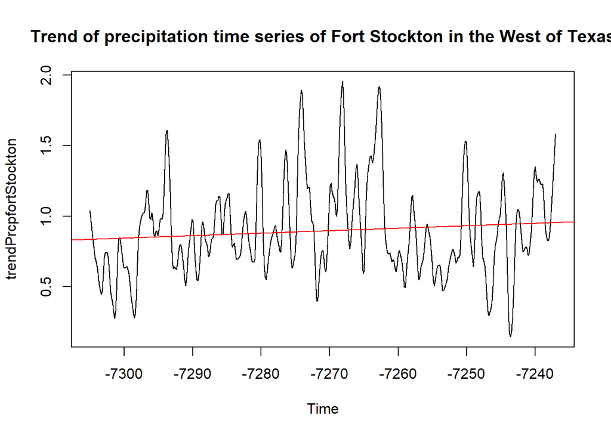

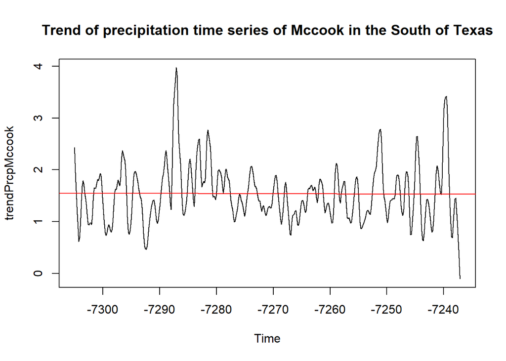

The autocorrelation plot of the precipitation time series of Angleton up to lag 365, shows that there is a significant autocorrelation up to lag 80. This means that the data is autocorrelated but not as strong as the temperature data for example. Unlike the temperature time series, it shows no periodicities since the seasonal component is much weaker here.

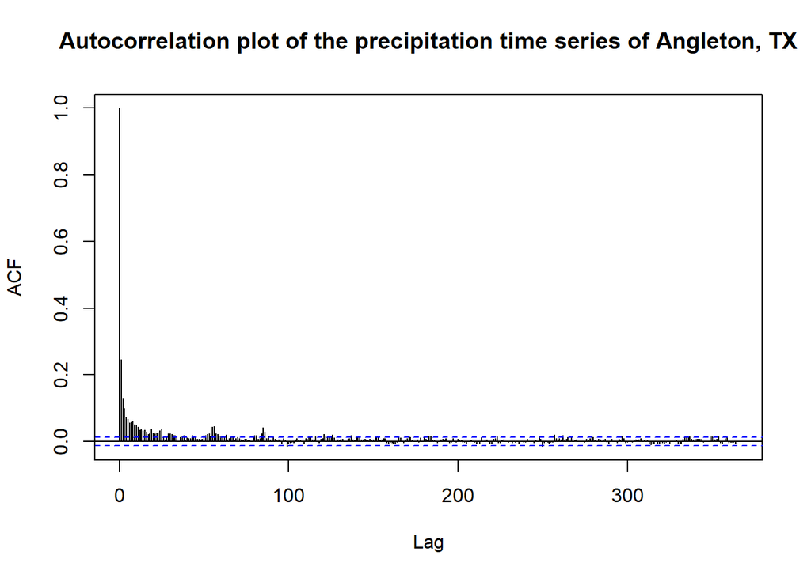

The forecast for the next 100 days is very constant. Nevertheless, a small increase is predicted for every station. Since all forecasts start at zero precipitation a little increase is not very surprising.

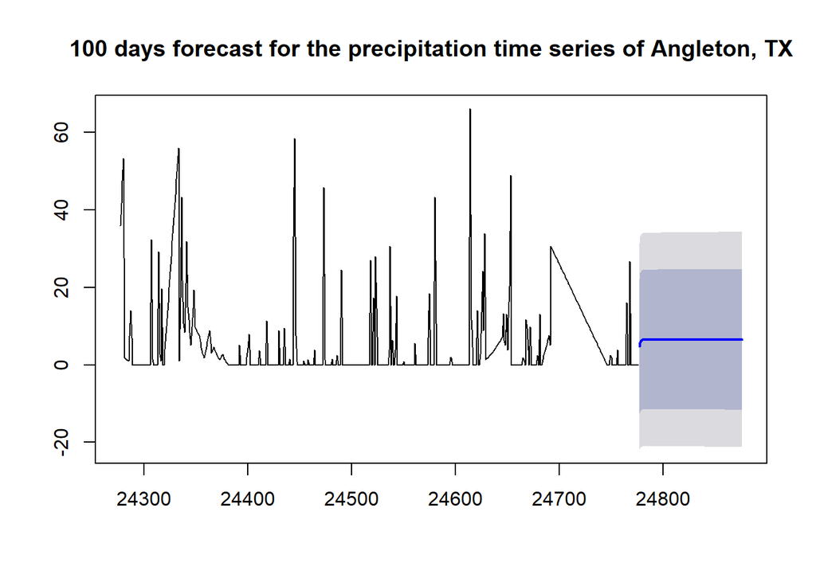

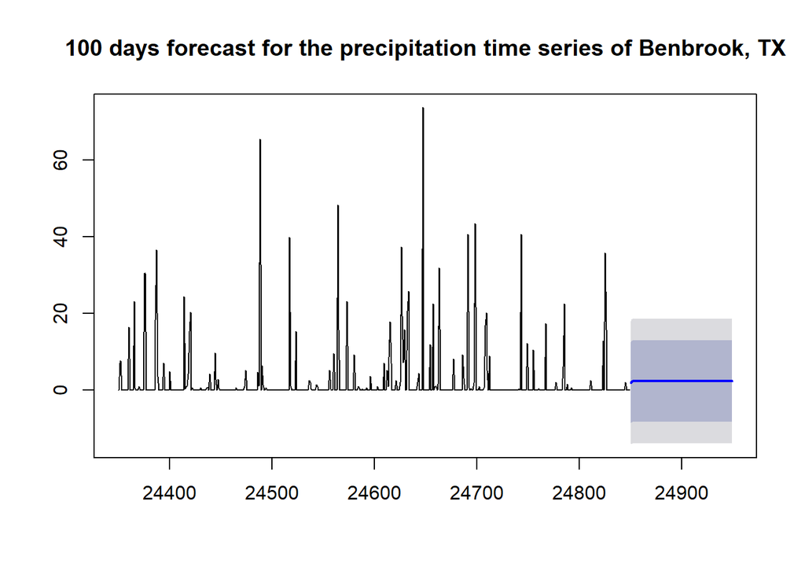

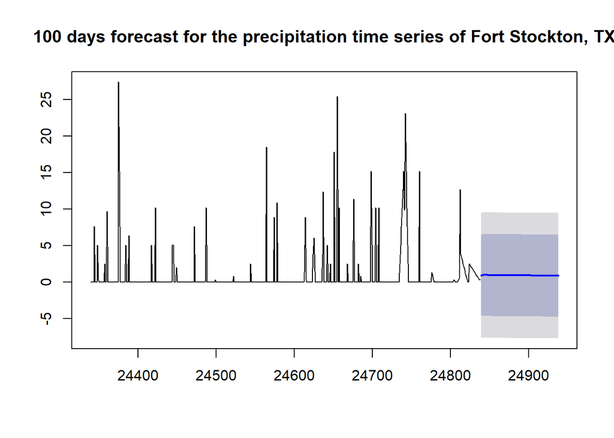

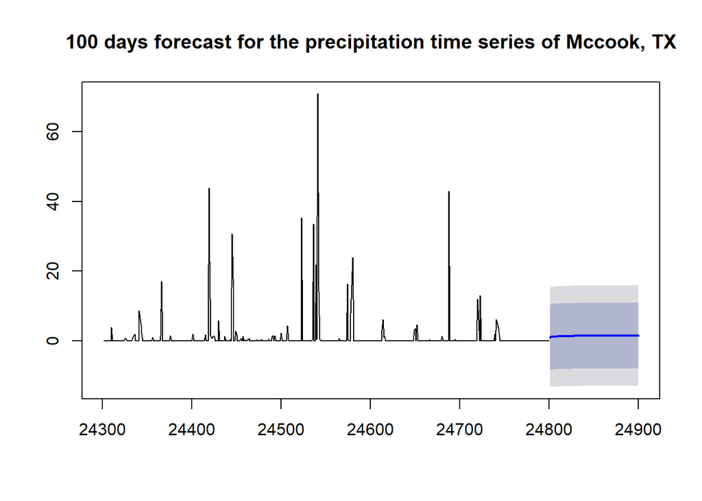

#### Averaged monthly data

The kriging interpolation of the averaged precipitation data for January supports the findings of the time series analysis and shows an increase in precipitation. It is not the maximum numbers which get higher but the areas with a high amount of rain become larger. The rainfall is always strongest in the regions in the east of Texas, adjacent to the Gulf of Mexico.

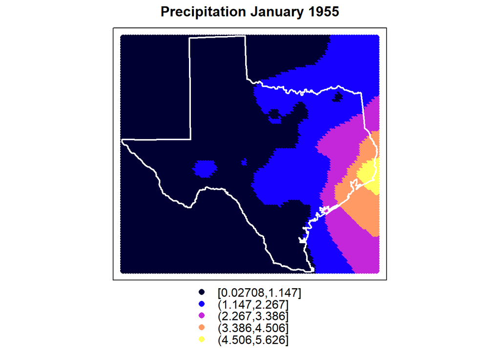

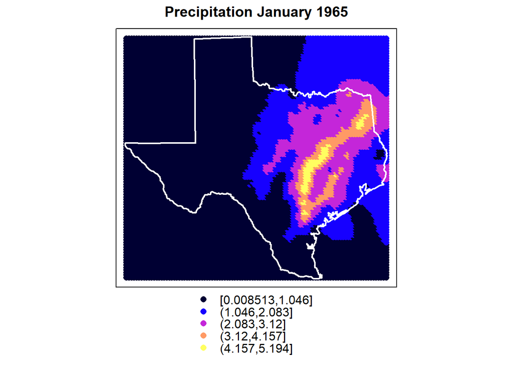

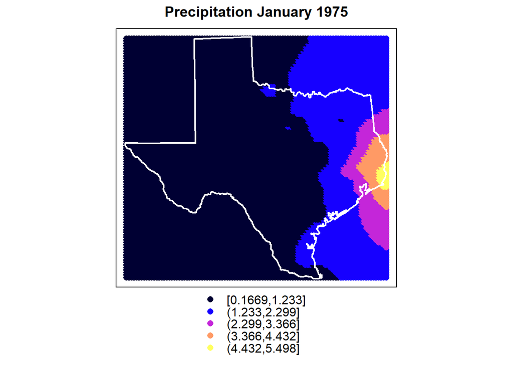

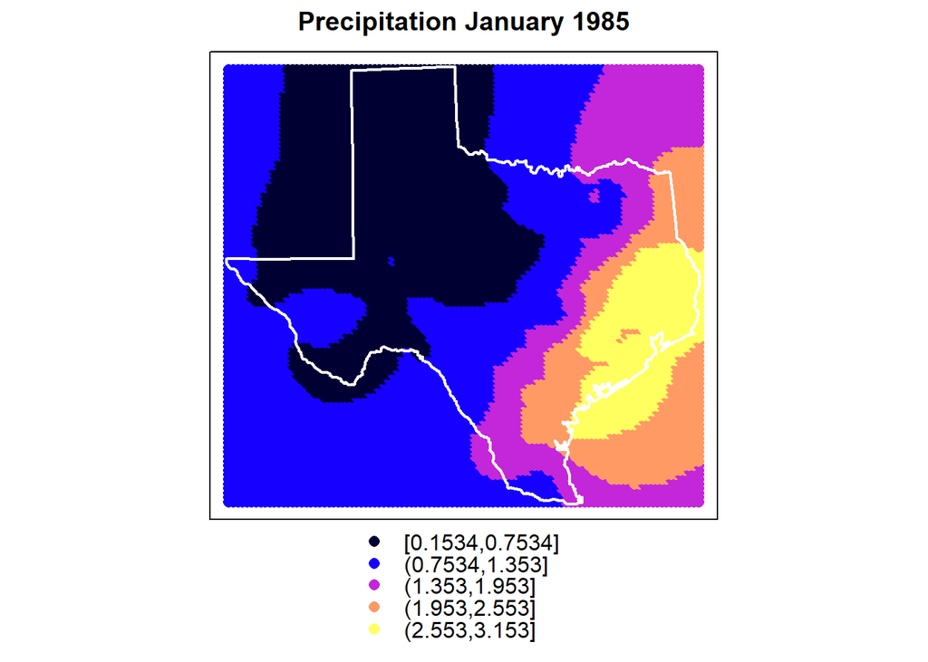

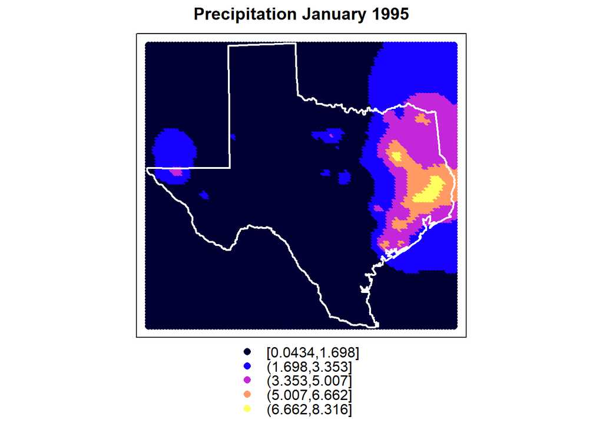

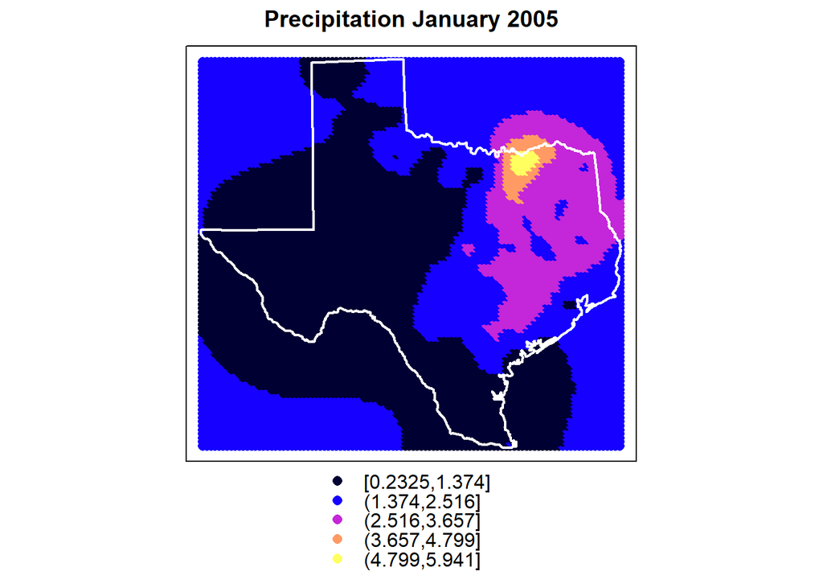

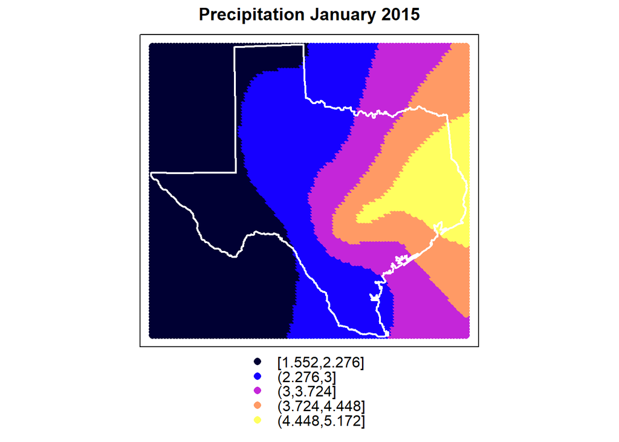

In addition to that, the comparison of the mean, minimum, maximum and standard deviation shows a noticeable rise from 1955 to 2015. The mean of the precipitation is twice as high in 2015 compared to ten years before and compared to 1955 the mean has risen by 2.2mm. The standard deviation is most high in 2015 but is still low enough to not be distorted by outliers.

Statistics of averaged Precipitation values in January

|  | Mean | Min | Max | Std. Dev. |
| --- | --- | --- | --- | --- |
| 1955 | 1.422093 | 0 | 7.4161 | 1.0363036 |
| 1965 | 1.604440 | 0 | 6.2871 | 1.3082966 |
| 1975 | 1.110685 | 0 | 6.8806 | 0.9037462 |
| 1985 | 1.315147 | 0 | 4.9194 | 0.9602849 |
| 1995 | 1.785836 | 0 | 12.2818 | 2.0100043 |
| 2005 | 1.773357 | 0 | 8.2839 | 1.1473095 |
| 2015 | 3.576365 | 0 | 14.9250 | 2.8434567 |
| Difference 2015 - 1955 | 2.154272 | 0 | 7.5089 | 1.8071531 |

Unlike the kriging results for January, the results for August are not that distinct. There are no big visible changes from 1955 until 2015. Different to January there is not only much precipitation at the coast but also in the north of Texas. The interpolation shows only very little rainfall for most parts of the state and mostly only the areas with the most predicted rainfall are changing.

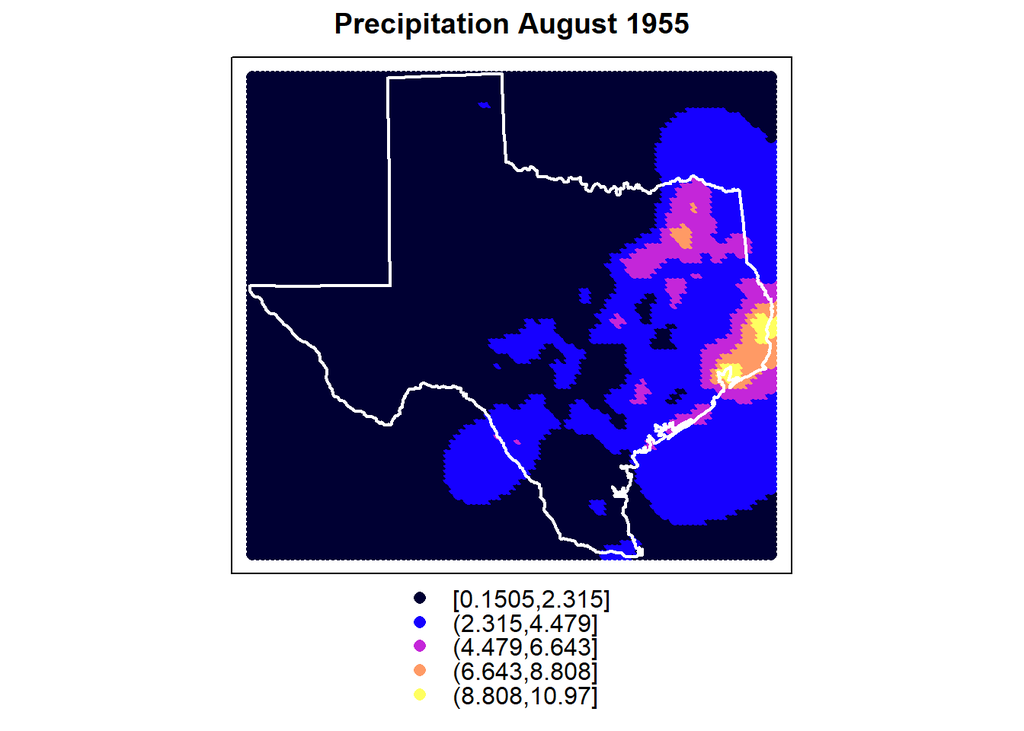

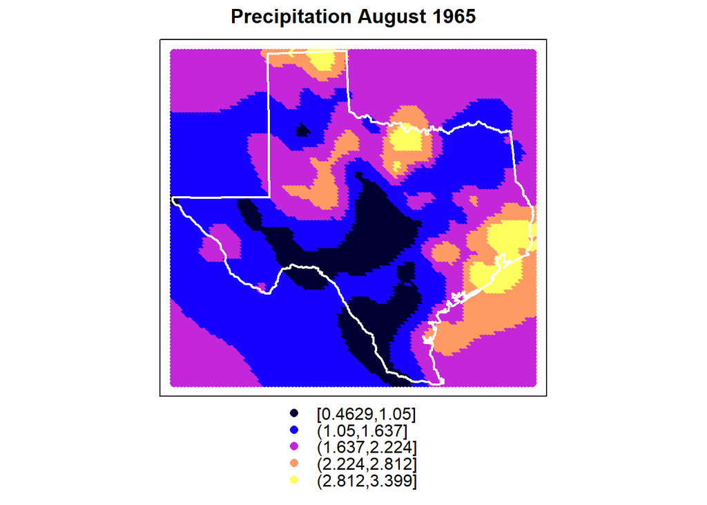

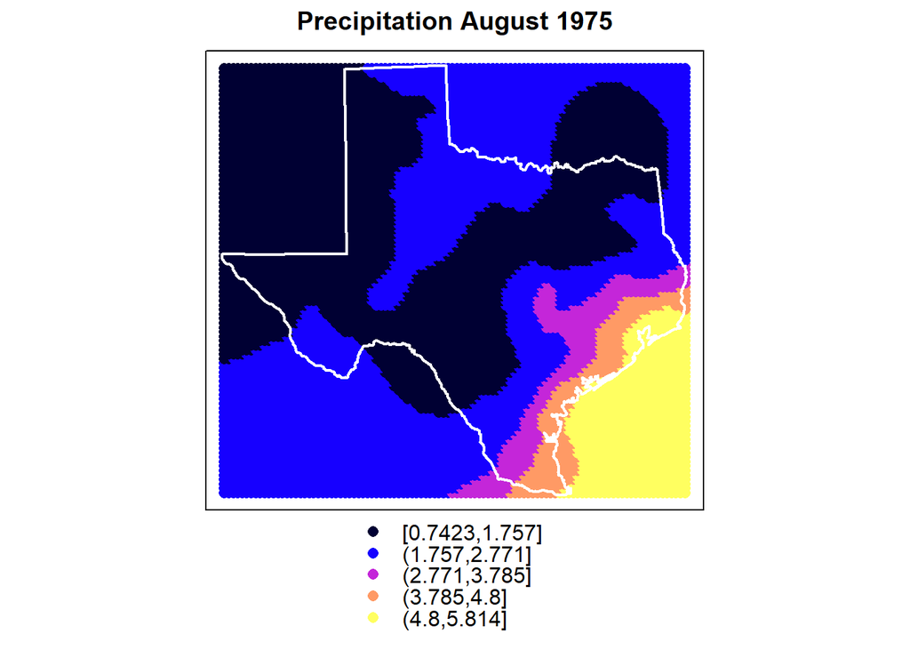

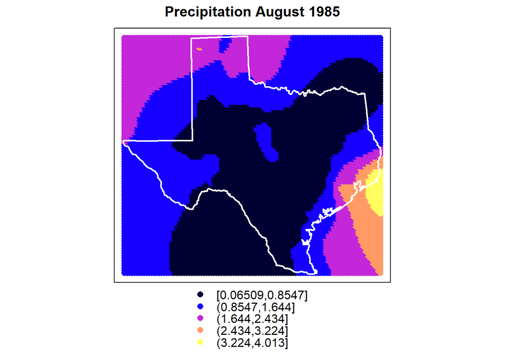

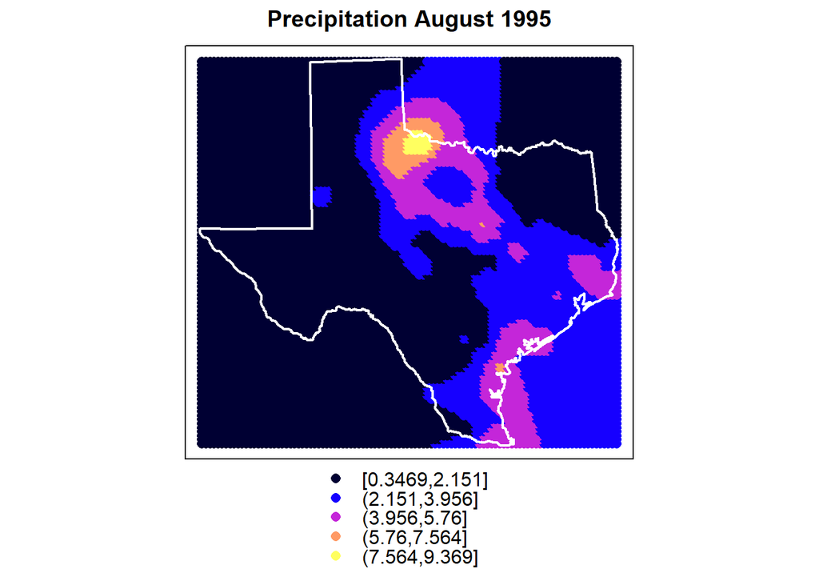

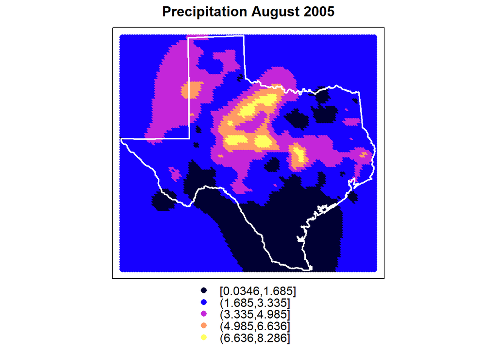

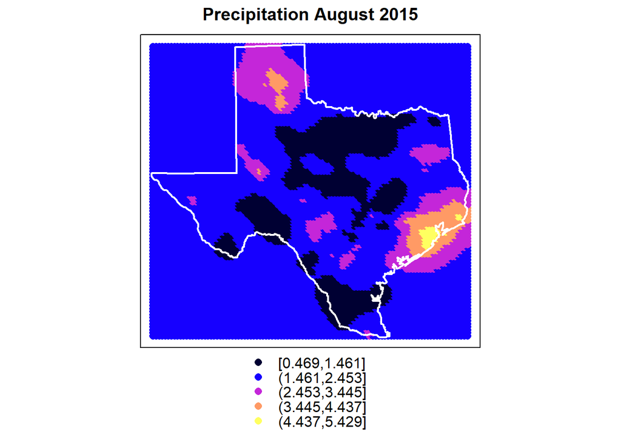

Interestingly, the comparison of the statistical values shows even a small decrease of rainfall in 2015. If you consider that 2005 and 1995 the mean precipitation was always higher than before this could be a sign for an unusual dry August in 2015. The high standard deviation and highest maximum in 2015 are a sign for heavier but more rare rainfall.

Statistics of averaged Precipitation values in August

|  | Mean | Min | Max | Std. Dev. |
| --- | --- | --- | --- | --- |
| 1955 | 2.3648000 | 0 | 14.1194 | 2.1666776 |
| 1965 | 1.6299850 | 0 | 5.7903 | 1.0411911 |
| 1975 | 2.1107771 | 0 | 9.9484 | 1.5380912 |
| 1985 | 0.8381998 | 0 | 9.2226 | 0.9554947 |
| 1995 | 2.5572382 | 0 | 14.4226 | 2.0192287 |
| 2005 | 2.7332627 | 0 | 10.3484 | 1.9452112 |
| 2015 | 1.9532624 | 0 | 14.8500 | 2.6973186 |
| Difference 2015 - 1955 | -0.4115376 | 0 | 0.7306 | 0.5306410 |

If you take both kriging results into account, you could speak of a small rise in precipitation even if the interpolation of August is not completely distinct.

#### Comparison coast interior

Matching the results of the kriging interpolation the comparison of the slope of the trend for the precipitation time series shows that the increase at the coast is three times higher than in the interior. Even if the slope in Mccook is decreasing, the steep slope in Angleton sets that off. Different to the temperature time series the changes are now higher at the coast.

Slope of trend of the Precipitation time series on the coast and in the interior

|  | Slope of trend |
| --- | --- |
| Angleton, East (Coast) | 0.0313092 |
| Mccook, South (Coast) | -0.0002986 |
| Benbrook, North (Interior) | 0.0067430 |
| Fort Stockton, West (Interior) | 0.0017494 |
| Mean (Coast) | 0.0155053 |
| Mean(Interior) | 0.0042462 |

### Evaporation

#### Time series data

The evaporation time series of the four stations in Texas do not cover the whole extent from 1950 until today. The time series of Angleton and Fort Stockton both start in the early 1950’s but end only ten years later in the early 1960’s. The time series of Mccook and Benbrook start in 1963 and 1979 but both reach until today. To be consistent, the measurements were still used in the analysis, but the results are not as meaningful as for the other measurements. Like in the temperature time series we can see yearly periodicities. In none of the time series a clear trend is visible but for the two stations with the longest series the peaks get higher with time.

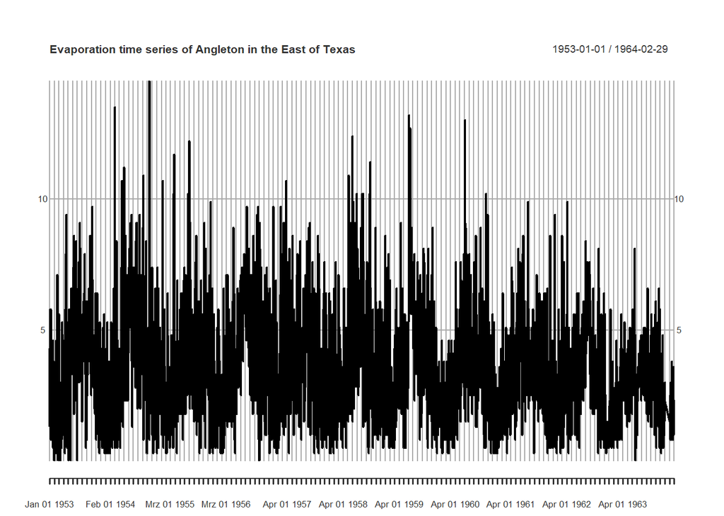

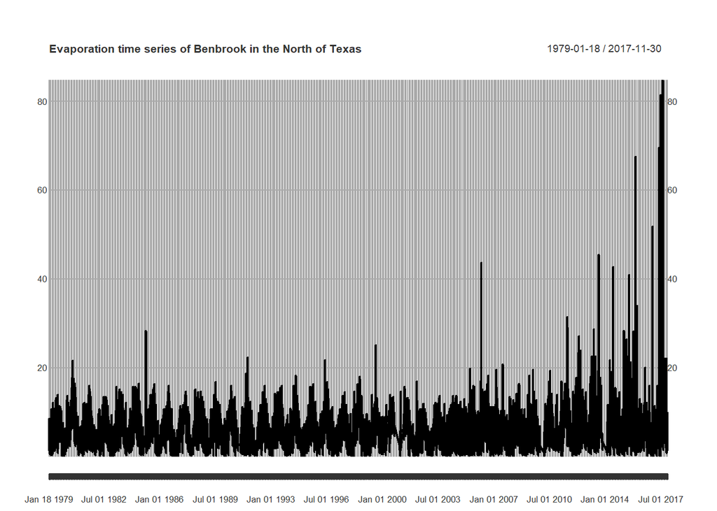

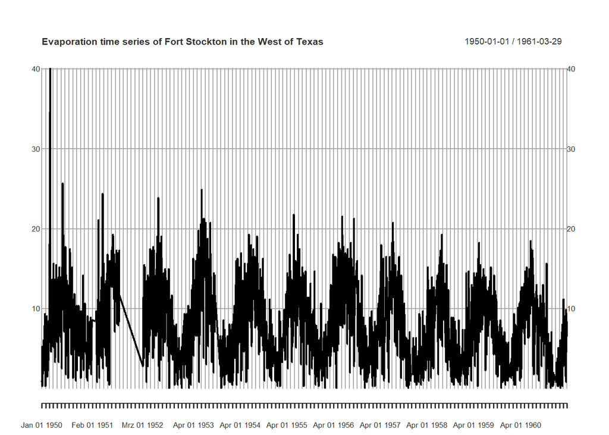

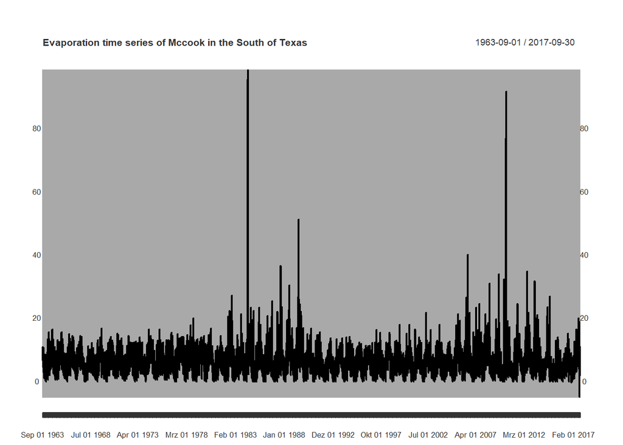

Different from the assumption that the evaporation should be increasing due to higher temperatures, the trend of three of the four stations is decreasing. Even if we leave out the stations with too little data, the time series of the longest period also shows a decreasing trend. According to research the increased cloud coverage and aerosol concentration leads to a decreased evaporation (Roderick and Farquhar, 2002). Nevertheless, the evaporation on sunny days seems to be stronger than former because of higher peaks at the end of the time series.

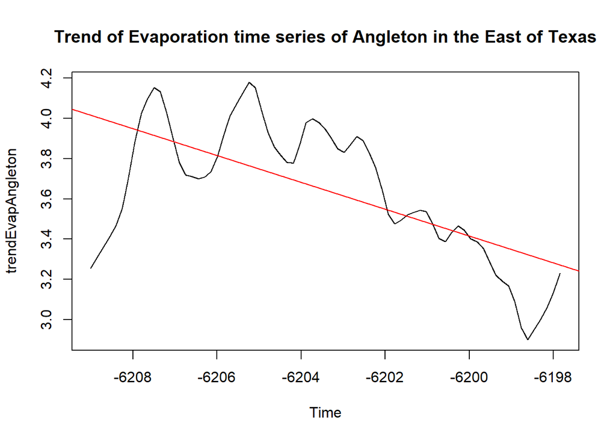